# Informe estadístico sobre la brecha laboral en cuestiones de género en Argentina (1982-2018)

Patricia Perrone y Marianela Pi

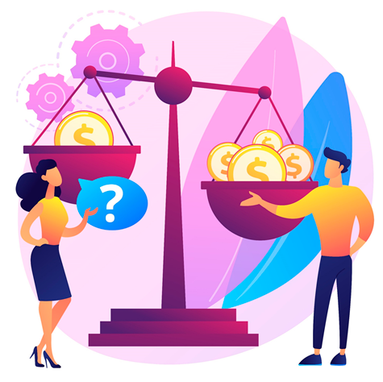

## Introducción

Los datos utilizados en este informe fueron tomados por el Banco Mundial sobre empleo/desempleo y género para algunos países de Latinoamérica y el Caribe, entre los años 1970 y 2018. Estos datos fueron provistos en formato de *data-frame* y contienen una cantidad de variables que aportan datos sobre el empleo/desempleo, tipo de empleo/actividad y legislación.

Para ajustar los datos al alcance de este análisis, se utilizarán sólo los datos de Argentina comprendidos entre los años 1982 y 2018, que es el período en donde Argentina relevó datos. Fuera de ese período no hay información disponible.

## Exploración de los datos

```r
# Código para cargar o leer los datos
# Filtramos por país (Argentina) y eliminamos las columnas de años que no tienen datos para simplificar el análisis

empleo_genero <- read.csv("datos/empleo_genero.csv")  |>
  filter(pais_region=="Argentina")  |>
  select(-pais_region, -codigo_pais_region)

empleo_genero <- empleo_genero[,-which(colMeans(is.na(empleo_genero)) == 1)]

# Transposición de los datos de la tabla
empleo_Arg <- pivot_longer(empleo_genero,
                           cols=2:36,
                           names_to = "Anio",
                           values_to = "porcentaje")

# reemplazo los valores de los años por el número correspondiente
# Convierto Anio a numérico

empleo_Arg <- empleo_Arg |>
  mutate(Anio = str_replace(Anio,"X",""),
         Anio = as.numeric(Anio))

# Llevamos la tabla a formato Tidy
empleo_Arg_ancho <- pivot_wider(empleo_Arg,
                                names_from = variable,
                                values_from = porcentaje)
```

### Desempleo

```r
# Comparación del desempleo por género, filtro variable por desempleo y agrego columna con el sexo
desempleo <- filter(empleo_Arg,variable %in% c("desempleo_mujeres","desempleo_hombres"))  |>
            mutate(sexo = ifelse(variable == "desempleo_mujeres","Mujer","Hombre"))

# Cálculo de estadísticos
mdesempleo <- desempleo  |>  group_by(variable)  |>
  summarise(media = mean(porcentaje,na.rm = TRUE),
            desvio = sd(porcentaje,na.rm = TRUE),
            max = max(porcentaje,na.rm = TRUE),
            min = min(porcentaje,na.rm = TRUE),
            rango = max-min)
```

#### Descripción y cantidad de observaciones

```r
str(desempleo)
```

```
## tibble [70 × 4] (S3: tbl_df/tbl/data.frame)
##  $ variable  : chr [1:70] "desempleo_mujeres" "desempleo_mujeres" "desempleo_mujeres" "desempleo_mujeres" ...
##  $ Anio      : num [1:70] 1982 1983 1984 1987 1988 ...
##  $ porcentaje: num [1:70] 5.4 4.8 4.19 6.6 7.2 ...
##  $ sexo      : chr [1:70] "Mujer" "Mujer" "Mujer" "Mujer" ...
```

Desempleo es una tabla de 4 variables y 70 observaciones. Deriva de la tabla empleo_Arg, y presenta sólo los datos de desempleo.

#### Valores estadísticos

```r
knitr::kable(mdesempleo)
```

| variable | media | desvio | max | min | rango |
| --- | --- | --- | --- | --- | --- |
| desempleo_hombres | 9.916752 | 4.630253 | 20.13 | 3.38 | 16.75 |
| desempleo_mujeres | 12.222180 | 5.191353 | 22.30 | 4.19 | 18.11 |

El primer análisis que podemos hacer es comparar ciertos datos estadísticos con respecto a la desocupación. En la siguiente tabla se puede observar la diferencia entre los valores con un promedio del 12.22 para las mujeres y del 9.91 para los hombres. Dentro de los datos no se encontró ninguna anomalía que sugiera que hay datos incorrectos o Valores imposibles.

```r
G1_1 <- ggplot(desempleo,aes(Anio,porcentaje, fill = sexo)) + geom_col(position=position_dodge()) +
  #scale_fill_manual(values=c("#DC143C", "#2E8B57")) +
  theme_classic()+
labs(title = "Gráfico 1 - Desempleo por género y año")
```

```r
G1_2 <- ggplot(desempleo,aes(Anio,porcentaje)) +
  geom_line(aes(color = sexo),lwd = 1.2)+
  theme_classic()
 #scale_color_manual(values=c("#DC143C", "#2E8B57"))
```

```r
# Cálculo de estadísticos desempleo
mdesempleo <- desempleo  |>
  group_by(variable) |>
  summarise(media = mean(porcentaje,na.rm = TRUE))

mdesempleo2 <- mdesempleo |>
  mutate(csum = rev(cumsum(rev(media))),
         pos = media/2 + lead(csum, 1),
         pos = if_else(is.na(pos), media/2, pos),
         media = round(media, 2))



G1_3 <- ggplot(mdesempleo, aes(x = "" , y = media, fill = variable)) +
  #scale_fill_manual(values=c("#DC143C", "#2E8B57")) +
  geom_col(width = 1, color = 1) +
  coord_polar(theta = "y") +
  geom_label_repel(data = mdesempleo2,
                   aes(y = pos, label = paste0(media, "%")),
                   size = 4.5, nudge_x = 1, show.legend = FALSE) +
  guides(fill = guide_legend(title = "% Promedio")) +
  #theme_void()
theme_classic()
```

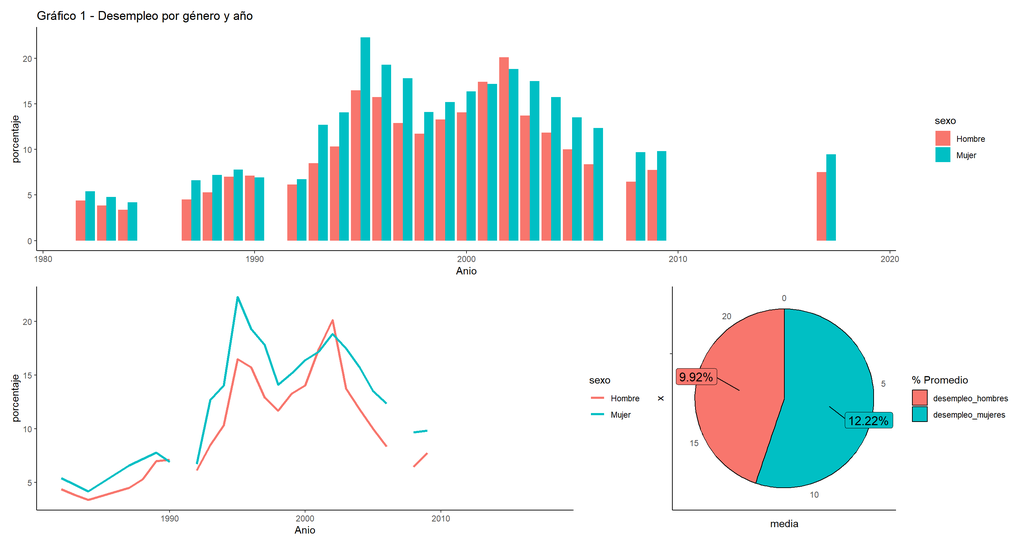

```r
G1_1 / (G1_2 + G1_3)
```

### Desempleo calificado

```r
# Comparación del desempleo por género, filtro variable por desempleo y agrego columna con el sexo
desempleo_calificado <- filter(empleo_Arg,variable %in% c("desempleo_educacion_mujeres","desempleo_educacion_hombres"))  |>
            mutate(sexo = ifelse(variable == "desempleo_educacion_mujeres","Mujer","Hombre"))

# Retiro los años sin datos para acrotar el gráfico
desempleo_calificado <- filter(desempleo_calificado, Anio > "2000")
```

Esta tabla contiene 36 casos y la información sobre los desempleados hombres y mujeres con educación terciaria, por año.

#### Descripción y cantidad de observaciones en desempleo calificado

```r
# Cálculo de estadísticos desempleo calificado
mdescal <- desempleo_calificado  |>
  group_by(variable) |>
  summarise(media = mean(porcentaje,na.rm = TRUE),
            desvio = sd(porcentaje,na.rm = TRUE),
            max = max(porcentaje,na.rm = TRUE),
            min = min(porcentaje,na.rm = TRUE),
            rango = max-min)

str(desempleo_calificado)
```

```
## tibble [36 × 4] (S3: tbl_df/tbl/data.frame)
##  $ variable  : chr [1:36] "desempleo_educacion_mujeres" "desempleo_educacion_mujeres" "desempleo_educacion_mujeres" "desempleo_educacion_mujeres" ...
##  $ Anio      : num [1:36] 2001 2002 2003 2004 2005 ...
##  $ porcentaje: num [1:36] NA 14.5 13.69 6.75 5.66 ...
##  $ sexo      : chr [1:36] "Mujer" "Mujer" "Mujer" "Mujer" ...
```

#### Valores estadísticos

```r
knitr::kable(mdescal)
```

| variable | media | desvio | max | min | rango |
| --- | --- | --- | --- | --- | --- |
| desempleo_educacion_hombres | 4.100385 | 3.333397 | 12.99 | 1.8024 | 11.1876 |
| desempleo_educacion_mujeres | 5.916315 | 3.739132 | 14.50 | 3.5257 | 10.9743 |

La población de mujeres con nivel terciario desempleadas llega casi al 6%, mientras que los varones apenas superan el 4%. Si bien las credenciales educativas de las mujeres parecieran favorecer su participación en el mercado de trabajo, cuando analizamos los datos como mujeres trabajadoras sigue en evidencia la situación de desventaja para ellas.

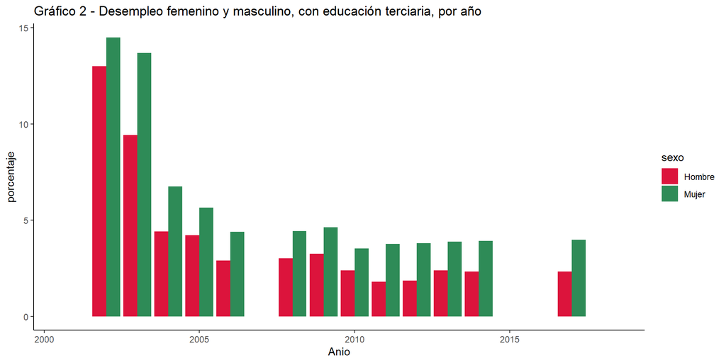

```r
# Gr;afico de desempleo calificado

G2 <- ggplot(desempleo_calificado,aes(Anio,porcentaje, fill = sexo, na.rm = TRUE)) +
  theme_classic()+
  geom_col(position=position_dodge()) +
  scale_fill_manual(values=c("#DC143C", "#2E8B57")) +
  labs(title = "Gráfico 2 - Desempleo femenino y masculino, con educación terciaria, por año")

G2
```

### Tipos de actividad

Esta tabla contiene información sobre el tipo de actividad realizada en el empleo. También está por género y año. Una observación a tener en cuenta es que, si bien se releva el empleo parcial para las mujeres, no se relevó para los hombres. Debido a que esta variable no puede ser comparada, la dejaremos para más adelante y no forma parte de este conjunto de datos.

```r
# Armo una tabla por tipo de empleo y agrego la columna sexo igual que en desempleo

tipo_empleo <- filter(empleo_Arg,variable %in% c("empleo_agricultura_mujeres","empleo_agricultura_hombres","empleo_industria_mujeres","empleo_industria_hombres","empleo_servicios_mujeres","empleo_servicios_hombres","empleo_informal_mujeres","empleo_informal_hombres","autoempleo_mujeres","autoempleo_hombres"))  |>
               mutate(sexo = ifelse(str_detect(variable,"mujeres"),"Mujer","Hombre"))  |>
               mutate(tipo = substring(variable,8,str_length(variable)-8))

# Corrijo el "autoempleo"
tipo_empleo$tipo <- str_replace(tipo_empleo$tipo, "leo", "autoempleo")
```

#### Descripción y cantidad de observaciones en tipo de actividad

```r
str(tipo_empleo)
```

```
## tibble [350 × 5] (S3: tbl_df/tbl/data.frame)
##  $ variable  : chr [1:350] "empleo_agricultura_mujeres" "empleo_agricultura_mujeres" "empleo_agricultura_mujeres" "empleo_agricultura_mujeres" ...
##  $ Anio      : num [1:350] 1982 1983 1984 1987 1988 ...
##  $ porcentaje: num [1:350] NA NA NA NA NA ...
##  $ sexo      : chr [1:350] "Mujer" "Mujer" "Mujer" "Mujer" ...
##  $ tipo      : chr [1:350] "agricultura" "agricultura" "agricultura" "agricultura" ...
```

#### Valores estadísticos de tipo de actividad

```r
# Cálculo de estadísticos desempleo calificado
mtempleo <- tipo_empleo  |>
  group_by(variable)  |>
  summarise(media = mean(porcentaje,na.rm = TRUE),
            desvio = sd(porcentaje,na.rm = TRUE),
            max = max(porcentaje,na.rm = TRUE),
            min = min(porcentaje,na.rm = TRUE),
            rango = max-min)

knitr::kable(mtempleo)
```

| variable | media | desvio | max | min | rango |
| --- | --- | --- | --- | --- | --- |
| autoempleo_hombres | 22.7365358 | 1.6157118 | 27.032 | 19.944 | 7.087999 |
| autoempleo_mujeres | 18.2403571 | 2.8329900 | 24.725 | 14.876 | 9.849000 |
| empleo_agricultura_hombres | 1.0274286 | 0.5492398 | 1.874 | 0.089 | 1.785000 |
| empleo_agricultura_mujeres | 0.3238571 | 0.2375489 | 0.974 | 0.015 | 0.959000 |
| empleo_industria_hombres | 33.5816071 | 3.0512160 | 41.123 | 27.905 | 13.218000 |
| empleo_industria_mujeres | 11.2580716 | 2.9704226 | 19.767 | 8.326 | 11.441000 |
| empleo_informal_hombres | 49.8754546 | 3.7797895 | 57.320 | 46.880 | 10.439999 |
| empleo_informal_mujeres | 51.6872725 | 5.6045263 | 62.050 | 46.470 | 15.579998 |
| empleo_servicios_hombres | 65.3908928 | 2.8452150 | 70.749 | 58.405 | 12.344002 |
| empleo_servicios_mujeres | 88.4180355 | 2.9851998 | 91.520 | 80.097 | 11.422996 |

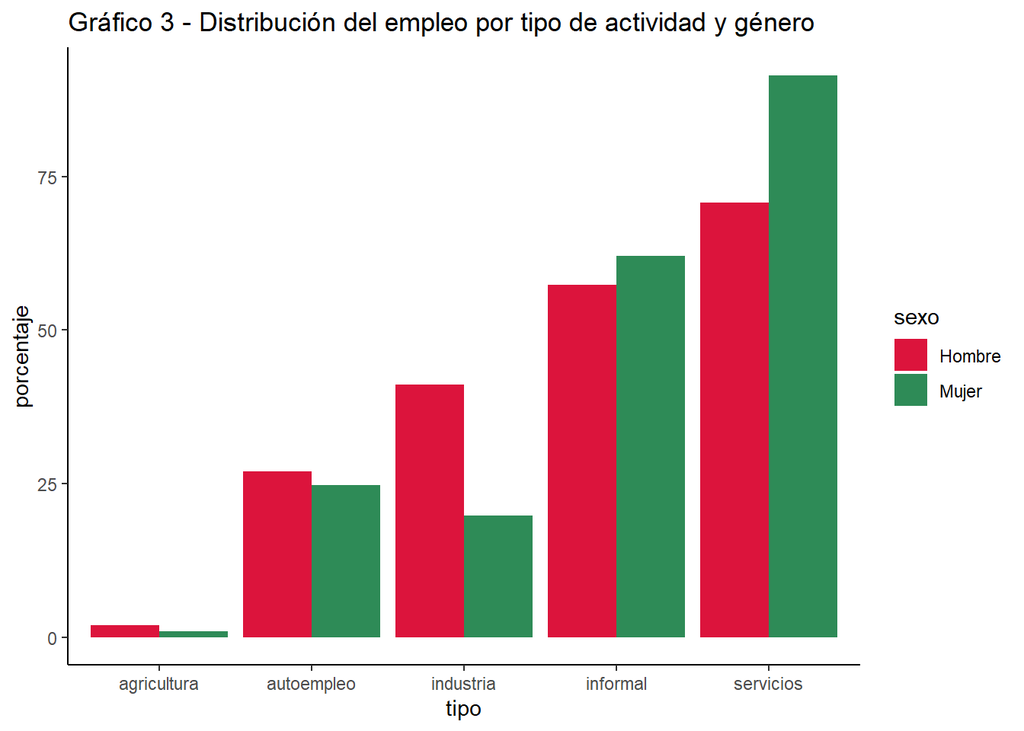

```r
# Grafico por tipo de actividad

G3 <- ggplot(tipo_empleo,aes(tipo,porcentaje, fill = sexo)) +
  geom_col(position=position_dodge()) +
  scale_fill_manual(values=c("#DC143C", "#2E8B57")) +
  theme_classic()+
  labs(title = "Gráfico 3 - Distribución del empleo por tipo de actividad y género")

G3
```

### Empleo doméstico

```r
empleo_domestico <- filter(empleo_Arg,variable %in% c("trabajo_domestico_no_remunerado_mujeres","trabajo_domestico_no_remunerado_hombres")) |>
                    mutate(sexo = ifelse(variable == "trabajo_domestico_no_remunerado_mujeres","Mujer","Hombre"))

# Retiro los años sin datos para acortar el gráfico
empleo_domestico <- filter(empleo_domestico, Anio > "2003")
```

#### Cantidad de observaciones en empleo doméstico

Aquí tenemos 30 observaciones. Esta tabla computa sólo el empleo doméstico, no remunerado, en hombres y mujeres.

```r
str(empleo_domestico)
```

```
## tibble [30 × 4] (S3: tbl_df/tbl/data.frame)
##  $ variable  : chr [1:30] "trabajo_domestico_no_remunerado_mujeres" "trabajo_domestico_no_remunerado_mujeres" "trabajo_domestico_no_remunerado_mujeres" "trabajo_domestico_no_remunerado_mujeres" ...
##  $ Anio      : num [1:30] 2004 2005 2006 2007 2008 ...
##  $ porcentaje: num [1:30] NA 16.7 NA NA NA ...
##  $ sexo      : chr [1:30] "Mujer" "Mujer" "Mujer" "Mujer" ...
```

#### Valores estadísticos en empleo doméstico

```r
medomestico <- empleo_domestico  |>
  group_by(variable)  |>
  summarise(media = mean(porcentaje,na.rm = TRUE),
            desvio = sd(porcentaje,na.rm = TRUE),
            max = max(porcentaje,na.rm = TRUE),
            min = min(porcentaje,na.rm = TRUE),
            rango = max-min)

knitr::kable(medomestico)
```

| variable | media | desvio | max | min | rango |
| --- | --- | --- | --- | --- | --- |
| trabajo_domestico_no_remunerado_hombres | 7.318978 | 1.688686 | 9.248601 | 6.111111 | 3.137490 |
| trabajo_domestico_no_remunerado_mujeres | 19.218250 | 3.657641 | 23.418640 | 16.736111 | 6.682529 |

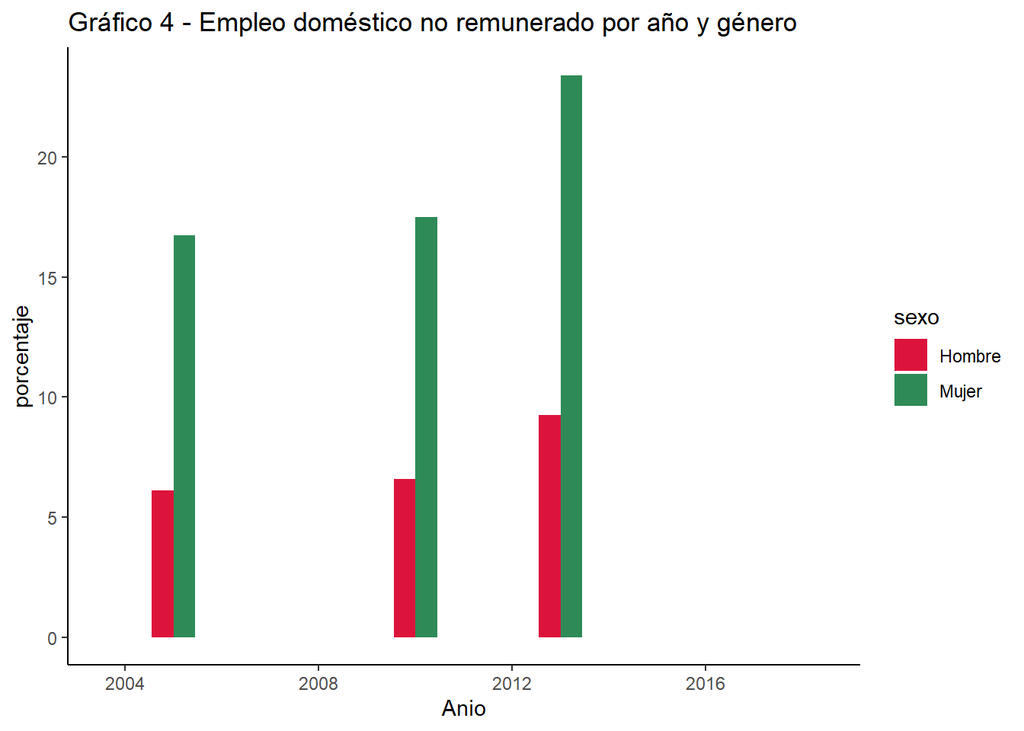

```r
G4 <- ggplot(empleo_domestico,aes(Anio,porcentaje, fill = sexo)) +
  geom_bar(stat = "Identity",position=position_dodge()) +
  scale_fill_manual(values=c("#DC143C", "#2E8B57")) +
  theme_classic()+
  labs(title = "Gráfico 4 - Empleo doméstico no remunerado por año y género")

G4
```

Es imposible imaginar un mundo en el cual no exista quien realice las tareas cotidianas de la vida, como alimentar a un/a bebé, limpiar la casa o hacer las compras. Lamentablemente es una tarea que se asocia al rol femenino y actualmente sigue habiendo una brecha muy marcada donde en los datos estadísticos la media nos muestra un 19.21% para las mujeres y un 7.31% para los hombres.

```r
empleadores <- filter(empleo_Arg, variable %in% c("empleadoras_mujeres","empleadores_hombres")) |>
  mutate(sexo = ifelse(variable == "empleadoras_mujeres","Mujer","Hombre"))
```

```r
mempempleadores <- empleadores  %>%
  group_by(variable)  %>%
  summarise(media = mean(porcentaje,na.rm = TRUE),
            desvio = sd(porcentaje,na.rm = TRUE),
            max = max(porcentaje,na.rm = TRUE),
            min = min(porcentaje,na.rm = TRUE),
            rango = max-min)

knitr::kable(mempempleadores)
```

| variable | media | desvio | max | min | rango |
| --- | --- | --- | --- | --- | --- |
| empleadoras_mujeres | 2.492964 | 0.2816652 | 3.205 | 1.915 | 1.290 |
| empleadores_hombres | 5.629321 | 0.8607130 | 7.492 | 4.293 | 3.199 |

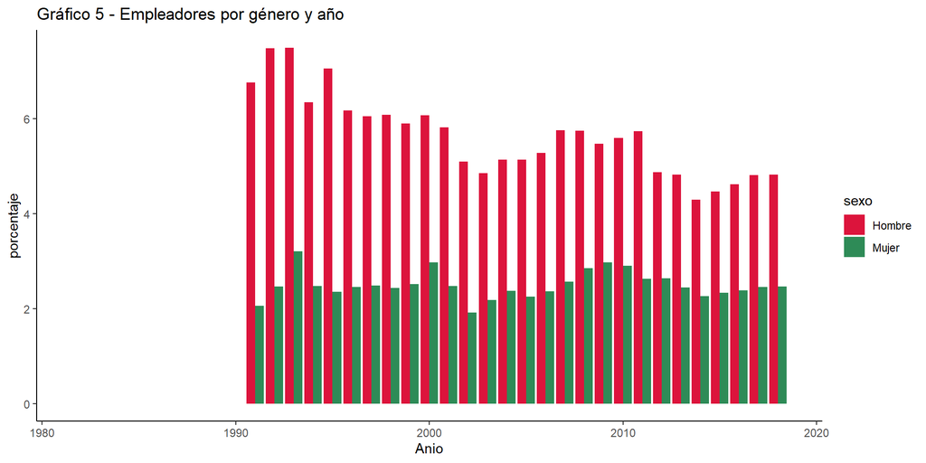

```r
G5 <- ggplot(empleadores, aes(Anio,porcentaje, fill = sexo, na.rm = TRUE)) +
  geom_col(position=position_dodge()) +
  scale_fill_manual(values=c("#DC143C", "#2E8B57")) +
  theme_classic()+
  labs(title = "Gráfico 5 - Empleadores por género y año")

G5
```

## Hipótesis

La igualdad de género es un derecho fundamental y crucial para el desarrollo sostenible, sin embargo aún se observan marcadas diferencias entre mujeres y hombres en los mercados de trabajo de todos los países del mundo. Algunas de las preguntas que nos hacemos son las siguientes:**¿Existe una brecha de desempleo de acuerdo al género de las personas?, ¿Las mujeres con el mismo nivel académico que los hombres tienen las mismas oportunidades de ocupar un puesto jerárquico?, ¿y cuando hablamos de cargos jerárquicos?, ¿qué tanta diferencia hay entre los ingresos de los hombres y de las mujeres?, ¿Los trabajos domésticos, le restan tiempo a las mujeres para realizar trabajo remunerado?, ¿Está asociado el trabajo doméstico con el trabajo informal? ¿Las mujeres pueden desarrollarse en cualquier tipo de empleo o el sistema las condiciona a realizar determinadas tareas?**.

## Tesis

En esta segunda parte del informe intentaremos contestar algunas de las preguntas que nos surgieron al trabajar los datos.

La primer pregunta que surgió al encarar este proyecto fue **¿Existe una brecha de desempleo de acuerdo al género de las personas?**

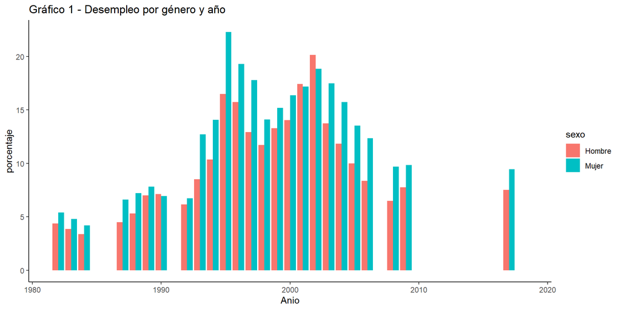

```r
G1_1
```

Quizás viendo los datos anteriores uno pensaría que esa brecha puede originarse en la falta de educación o que los hombres están más preparados académicamente que las mujeres y de esa manera tener más oportunidades en el campo laboral dejando de lado la famosa teoría del techo de cristal, esa barrera invisible que impide que las mujeres alcancen las mismas posiciones de poder que los hombres y que está relacionada directamente con las normas y los estereotipos. Ahí nos surgen las siguientes preguntas **¿Las mujeres con el mismo nivel académico que los hombres tienen las mismas oportunidades de ocupar un puesto jerárquico?, ¿y cuando hablamos de cargos jerárquicos? ¿qué tanta diferencia hay entre los ingresos de los hombres y de las mujeres?**

Si bien el desempleo calificado es generalizado tanto para la mujer como para el hombre, la mujer tiende a tener un índice mayor de desempleo generando una brecha porcentual del 1.81. Viendo este número uno pensaría que la brecha de empleadores/as estaría rondando en un porcentaje similar si existiesen las mismas oportunidades.

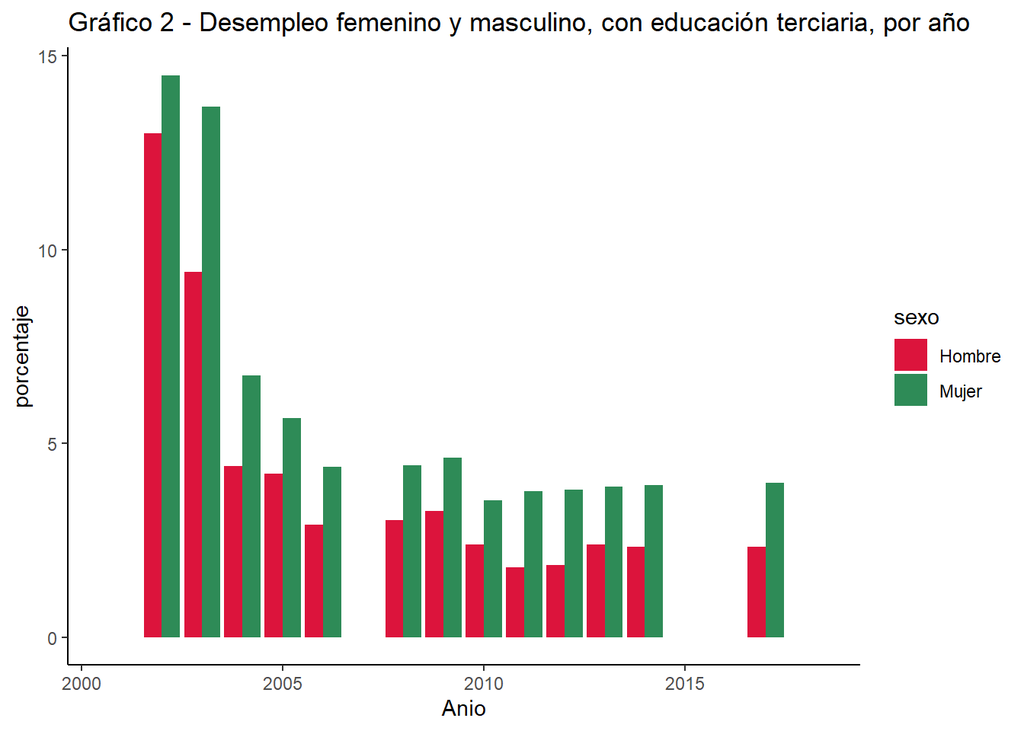

```r
# Grafico de desempleo calificado
G2
```

```r
empleadores <- filter(empleo_Arg, variable %in% c("empleadoras_mujeres","empleadores_hombres")) %>%
  mutate(sexo = ifelse(variable == "empleadoras_mujeres","Mujer","Hombre"))
```

En el gráfico 5 se hizo una comparativa con las variables desempleo nivel terciario y empleadores, donde nos muestra claramente la brecha. El porcentual de empleadores/as alcanza el 3.13 % cuando la diferencia de desempleo nivel terciario como mencionamos anteriormente era del 1.81 % y eso muestra la desventaja que existe entre el hombre y la mujer a la hora de tener oportunidades laborales. Finalmente podemos decir que la respuesta es que la mujer con el mismo nivel académico NO tiene las mismas oportunidades que el hombre de ocupar un puesto jerárquico o de ser empleadora.

```r
# Comparo las variables desempleo con empleo calificado eliminando los a;os que no tienen datos
Jefes_vs_desempleocal <- union(empleadores, desempleo_calificado) %>%
  filter(Anio > 1990)

# Calculo las medias por variable
mjefesdescal <- Jefes_vs_desempleocal %>%
  group_by(variable) %>%
  summarise(media = mean(porcentaje,na.rm = TRUE))
```

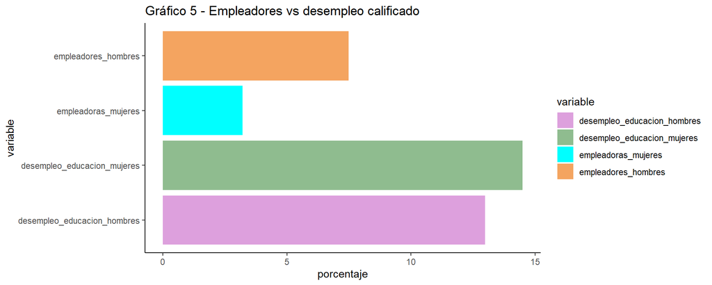

```r
G5 <- ggplot(Jefes_vs_desempleocal, aes(porcentaje, variable, fill = variable, na.rm = TRUE)) +
  geom_col(position=position_dodge()) +
  scale_fill_manual(values=c("#DDA0DD", "#8FBC8F", "#00FFFF", "#F4A460")) +
  theme_classic()+
  labs(title = "Gráfico 5 - Empleadores vs desempleo calificado")

G5
```

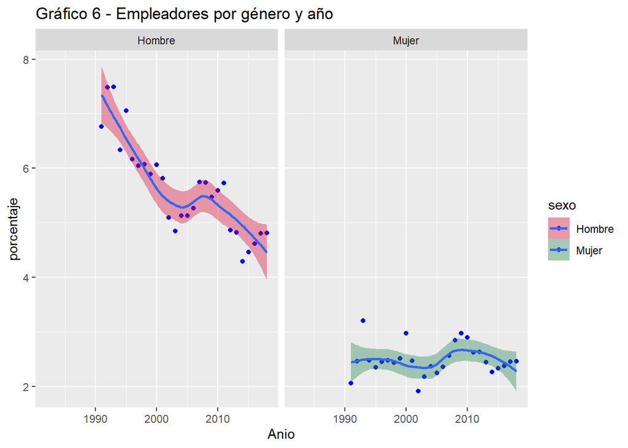

```r
G6 <- ggplot(empleadores, aes(Anio,porcentaje, fill = sexo)) +
  scale_fill_manual(values=c("#DC143C", "#2E8B57")) +
  ##theme_classic()+
  geom_point(colour = "blue") +
  geom_smooth() +

  labs(title = "Gráfico 6 - Empleadores por género y año")+
  facet_wrap(~sexo, ncol = 2)

G6
```

En el gráfico 6 podemos observar algo bastante particular, y es que, mientras el porcentaje promedio de empleadores tiene una clara caída con una pendiente bien marcada, el porcentaje de empleadoras se mantuvo bastante estable a través de los años observados, a pesar de que mostro una inflexión similar entre los años 2005 y 2007 aproximadamente. Si bien no tenemos datos suficientes para demostrarlo, nuestra sospecha es que la misma desigualdad ha provocado que las mujeres que logran alcanzar un puesto de jefas, lo hagan con mucha más solidez que los hombres, lo que en épocas de inestabilidad económica se traduzca en una menor caída en esos puestos de trabajo. Otro dato notable para destacar es que a pesar de existir una caida pronunciada en el porcentaje empleadores hombres, no existe una subida pronunciada en empleadoras mujeres que indique que fueron adquiriendo más oportunidades, por el contrario se mantuvo estable.

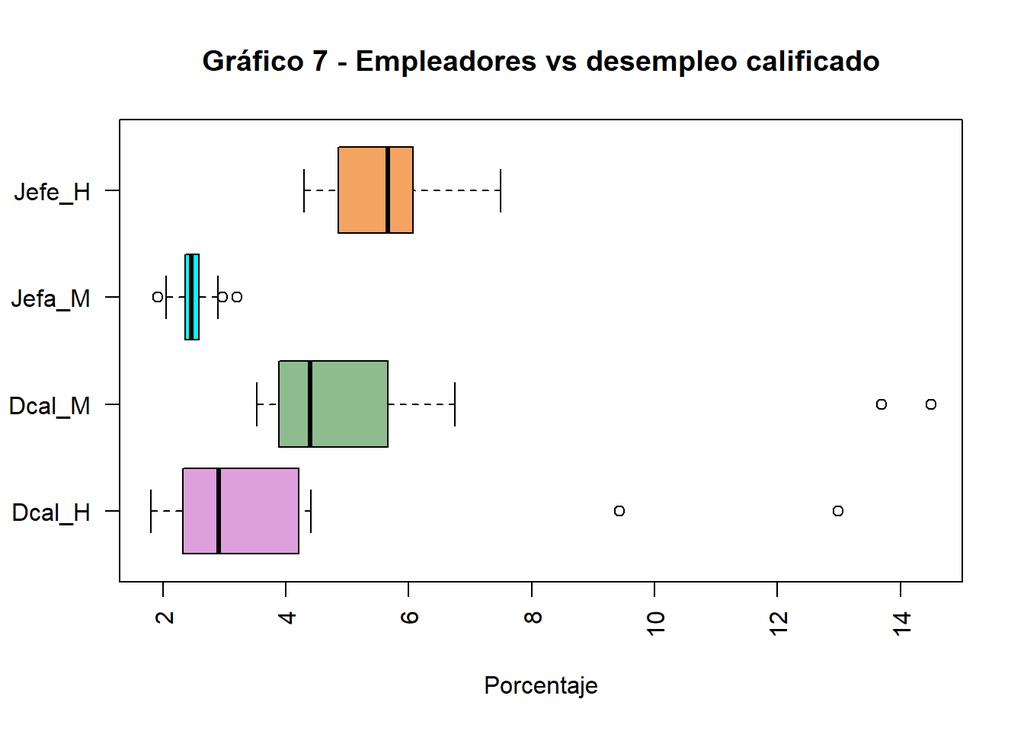

```r
Jefes_vs_desempleocal$variable <- str_replace(Jefes_vs_desempleocal$variable, "mujeres", "M")
Jefes_vs_desempleocal$variable <- str_replace(Jefes_vs_desempleocal$variable, "hombres", "H")
Jefes_vs_desempleocal$variable <- str_replace(Jefes_vs_desempleocal$variable, "desempleo_educacion", "Dcal")
Jefes_vs_desempleocal$variable <- str_replace(Jefes_vs_desempleocal$variable, "empleadores", "Jefe")
Jefes_vs_desempleocal$variable <- str_replace(Jefes_vs_desempleocal$variable, "empleadoras", "Jefa")

G7 <- boxplot(Jefes_vs_desempleocal$porcentaje ~ Jefes_vs_desempleocal$variable,
        horizontal = TRUE,
        col = c("#DDA0DD", "#8FBC8F", "#00FFFF", "#F4A460"),
        outbg = "#FF1493",
        ylab = "",
        xlab = "Porcentaje",
        las = 2)
  title ("Gráfico 7 - Empleadores vs desempleo calificado")
```

El gráfico 7 no sólo confirma sino que amplía lo que podemos observar en el gráfico 5. La dispersión en la variable jefas_mujeres es muy pequeña y casi todos los valores están muy cercanos a la media. Ni siquiera los valores extremos se apartan demasiado, a diferencia del caso de jefes_hombres.

#### La teoría de las paredes de cristal

Nos gustaría responder todas las preguntas, pero no hay datos relevados de los ingresos, aunque hay que tener en cuenta que dependiendo de la actividad que se desarrolla, determina una diferencia económica y eso nos obliga a hablar de la teoría de las paredes de cristal (obstáculos para que las mujeres accedan a ciertos sectores productivos), y eso hace que nos preguntemos **¿Las mujeres pueden desarrollarse en cualquier tipo de empleo o el sistema las condiciona a realizar determinadas tareas?**

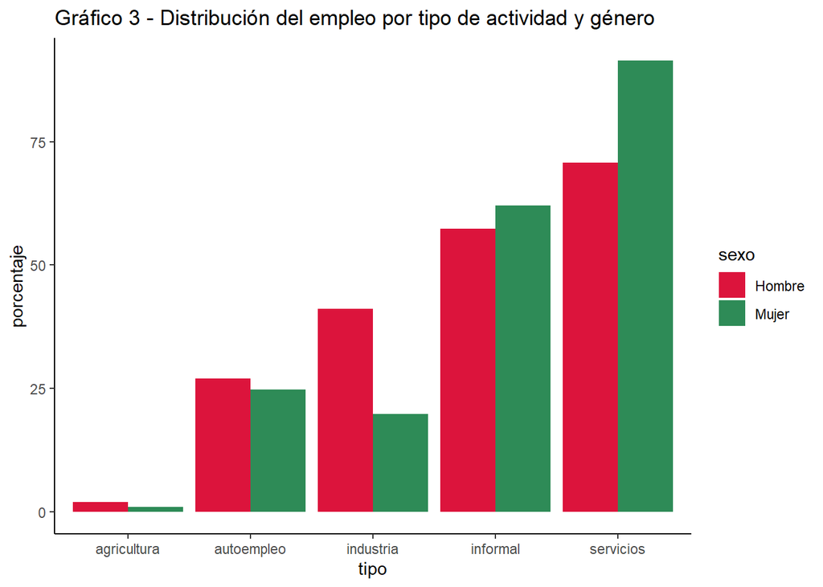

```r
# Grafico por tipo de actividad
G3
```

A continuación podemos ver las tablas con las medias de la distribución por tipo de empleo, tanto para hombres como para mujeres y uno de los datos que nos muestra la siguiente tabla es que la media en empleo parcial de mujeres llega casi al 60 y en los hombres no hay dato alguno.

```r
# Busco la distribución de la ocupación de las mujeres
actividades_mujeres <- empleo_Arg %>%
  mutate(sexo = ifelse(str_detect(variable,"mujeres"),"Mujer","Hombre")) %>%
  filter(sexo == "Mujer") %>%
  filter(variable != "desempleo_mujeres" & variable != "desempleo_educacion_mujeres") %>%
  group_by(variable) %>%
  summarise(media = mean(porcentaje,na.rm = TRUE))

head(actividades_mujeres,10) |>
  gt()
```

| variable | media |
| --- | --- |
| autoempleo_mujeres | 18.2403571 |
| empleadoras_mujeres | 2.4929643 |
| empleo_agricultura_mujeres | 0.3238571 |
| empleo_industria_mujeres | 11.2580716 |
| empleo_informal_mujeres | 51.6872725 |
| empleo_parcial_mujeres | 59.1512479 |
| empleo_servicios_mujeres | 88.4180355 |
| trabajo_domestico_no_remunerado_mujeres | 19.2182502 |

```r
G8 <- ggplot(actividades_mujeres, aes(media, variable, fill = variable)) +
  geom_col(position=position_dodge()) +
  theme_classic()+
  scale_x_continuous(breaks = get_breaks(by = 20, from = 0),
  limits = c(0, 100)) +
  labs(title = "Gráfico 8 - Distribución de la actividad femenina")
```

```r
# Busco la distribución de la ocupación de los hombres
actividades_hombres <- empleo_Arg %>%
  mutate(sexo = ifelse(str_detect(variable,"hombres"),"Hombre","Mujer")) %>%
  filter(sexo == "Hombre") %>%
  filter(variable != "desempleo_hombres" & variable != "desempleo_educacion_hombres") %>%
  group_by(variable) %>%
  summarise(media = mean(porcentaje,na.rm = TRUE))

head(actividades_hombres,10) |>
  gt()
```

| variable | media |
| --- | --- |
| autoempleo_hombres | 22.736536 |
| empleadores_hombres | 5.629321 |
| empleo_agricultura_hombres | 1.027429 |
| empleo_industria_hombres | 33.581607 |
| empleo_informal_hombres | 49.875455 |
| empleo_servicios_hombres | 65.390893 |
| trabajo_domestico_no_remunerado_hombres | 7.318978 |

#### “Eso que llaman amor, es trabajo no pago”

En el gráfico 8 tenemos la distribución de las actividades femenina, donde podemos apreciar que en gran porcentaje las mujeres realizan trabajo parcial, informal o trabajo doméstico lo que implica menos ingresos y nos preguntamos **¿Los trabajos domésticos, le restan tiempo a las mujeres para realizar trabajo remunerado?**

```r
# Busco la distribución de la ocupación de los hombres
actividades_hombres <- empleo_Arg %>%
  mutate(sexo = ifelse(str_detect(variable,"hombres"),"Hombre","Mujer")) %>%
  filter(sexo == "Hombre") %>%
  filter(variable != "desempleo_hombres" & variable != "desempleo_educacion_hombres") %>%
  group_by(variable) %>%
  summarise(media = mean(porcentaje,na.rm = TRUE))

head(actividades_hombres,10) |>
  gt()
```

| variable | media |
| --- | --- |
| autoempleo_hombres | 22.736536 |
| empleadores_hombres | 5.629321 |
| empleo_agricultura_hombres | 1.027429 |
| empleo_industria_hombres | 33.581607 |
| empleo_informal_hombres | 49.875455 |
| empleo_servicios_hombres | 65.390893 |
| trabajo_domestico_no_remunerado_hombres | 7.318978 |

```r
G9 <- ggplot(actividades_hombres, aes(media, variable, fill = variable)) +
  geom_col(position=position_dodge()) +
  theme_classic()+
  scale_x_continuous(breaks = get_breaks(by = 20, from = 0),
  limits = c(0, 80)) +
  labs(title = "Gráfico 9 - Distribución de la actividad masculina")
```

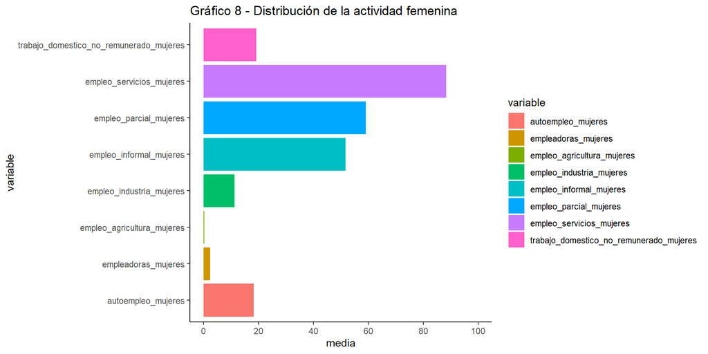

```r
G8
```

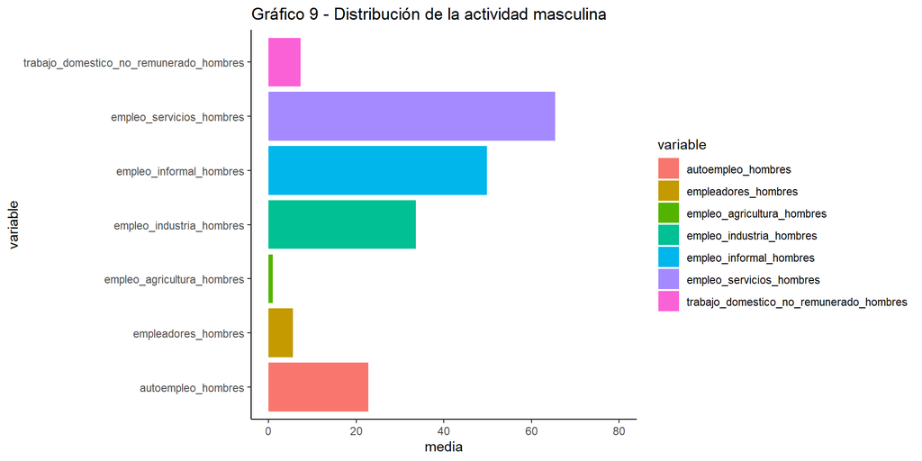

```r
G9
```

Efectivamente, la distribución de estas tareas entre los géneros es marcadamente desigual. El porcentaje del día utilizado por las mujeres para hacer tareas domésticas es de 19.21%, y los hombres, solo el 7.31%. Incluso una mujer que trabaja (fuera del hogar y de manera paga) en una jornada completa dedica más horas a estas tareas, en otros casos las mujeres trabajan en forma parcial o trabajo informal para dedicarle tiempo a la crianza de sus hijos o al cuidado de un familiar, ya que estas tareas en muchos casos le quitan tiempo para realizar trabajo remunerado, tal como nos indica la tabla donde nos muestra que la media del trabajo parcial en mujeres llega casi al 60 y en los hombres no hay datos. Así las cosas, las mujeres quedan inmersas en una suerte de círculo vicioso, en el que no sólo dedican gran parte de su tiempo a este tipo de tareas no remuneradas, sino que, al hacerlo, acrecientan sus desventajas con respecto al mercado laboral remunerado. Lamentablemente es una tarea que se asocia al rol femenino y a pesar que en los últimos años hay más participación en las tareas domésticas por parte de los hombres, la brecha sigue siendo importante como nos muestra el grafico 4.

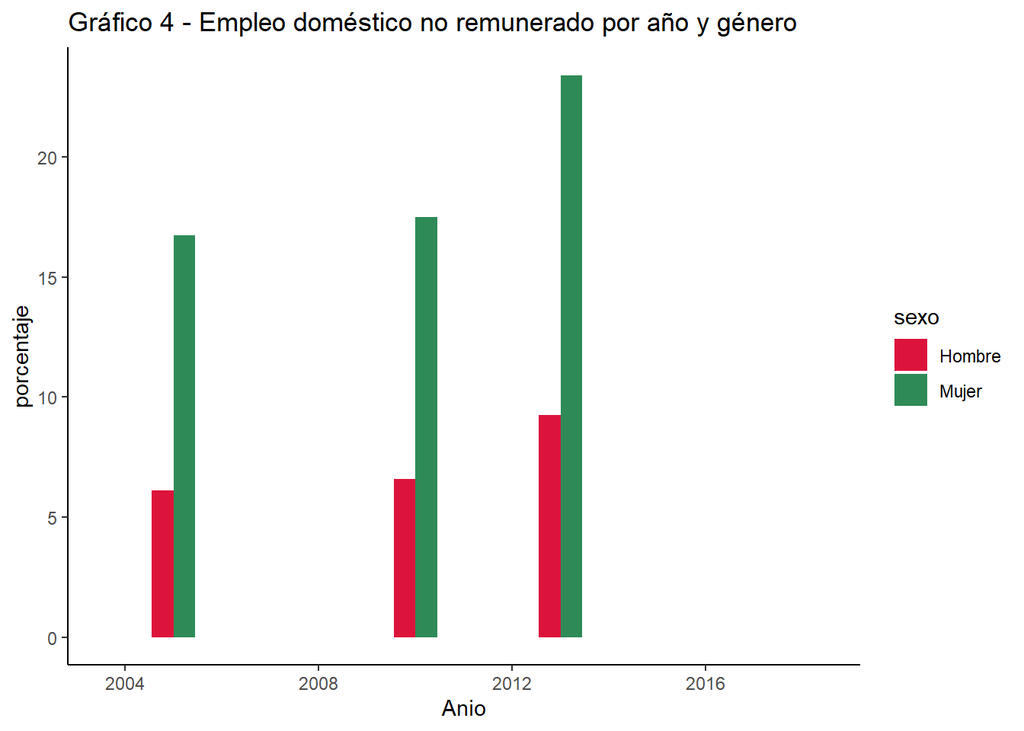

```r
# Gráfico de empleo doméstico
G4
```

## Conclusiones

Sin lugar a dudas, el análisis realizado permite concluir que aún existe una amplia brecha laboral de género. Si bien las mujeres representan la mitad de la población, su tasa de empleo sigue siendo más baja que la de los varones. La brecha con los hombres es todavía importante, y demuestra que a pesar de tener los mismos niveles de formación profesional las mujeres no tienen las mismas oportunidades y eso hace que el objetivo de igual remuneración por igual trabajo sea una promesa incumplida. Por último, cabe destacar que la mujer destina gran parte de su tiempo a las tareas domésticas. Estos aspectos dan cuenta de los roles atribuidos históricamente a varones y mujeres y su incidencia sobre el mercado de trabajo, donde el hombre se encarga del trabajo productivo y la mujer del trabajo reproductivo, restándole tiempo para realizar trabajo remunerado que le permita un mejor desarrollo económico.